# LPJ_Guess_Preliminary

Daniel Forcade

12/11/2021

# LPJ-Guess

This project is being worked on in collaboration with Charlotte Uden and Greta Savitsky. My primary role has been analyzing data provided by Charlotte to assist in her Ph.d thesis, specifically regarding outputs in the LPJ-Guess Dynamic Vegetation-Terrestrial Ecosystem Model. Charlotte seeks to use forest composition predicted by LPJ-Guess to understand the role of fire on the pre-European landscape of the Northeastern United States. The goal is to correctly model current environmental and testable metrics within LPJ_Guess, in an effort to extrapolate the parameters into the past, to enable predictive (Is it post-dictive when predicting the past?) analysis.

## Data Overview

The data provided for this analysis was 10 sets of 142,681 observations with 12 categories, totaling in 17,121,720 data points.  
The 10 sets were made up of different fire frequencies, ranging from 1 (Most) to 0 (Least). The categories were filled with the following six plant functional types (PFTs):

- BNT: Boreal Needleleaf Shade Tolerant
- BNI: Boreal Needleleaf Shade Intolerant
- TBT: Temperate Broadleaved Shade Tolerant
- BBI: Boreal Broadleaved Shade Intolerant
- TBI: Temperate Broadleaved Shade Intolerant
- TBIR: Temperate Broadleaved Shade Intolerant - Fire Resilient

Additionally, location data (Lat, Long), Year, and Total density for location was provided.

## Analysis

I was tasked with investigating if tree density changes with fire frequency, as well as viewing historical density outputs from the model.

Since I was not looking at geographical data for this specific investigation, I generated alternative datasets containing only relevant data (Lat/Long removal) to ease in both organization and accelerate processing time.

The analysis produced (Figure 1, Figure 2, Figure 3) is `Total Density` by `Year`, separated by `Fire Frequency`. In this, I wanted to investigate what type of effect `Fire Frequency` was having on the entire forest density ecosystem. Three test graphs were produced to determine which would be the best for relaying this information visually; we found each offers a unique utilization. Trends appear to hold consistent regardless of `Fire Frequency` with regards to `Year`, but I have not yet run a statistical test to verify.

What Figure 3 was able to clearly show, was that there was a jump in `Total Density` at `Fire Frequency` 0.05 and 1. I found this interesting, and set out to examine the data more closely, to see there were any PFT differences happening within these macro jumps; specifically, was the distribution equally distributed across the board.

#### Figure 1: Total Tree Density Through Year - Overview

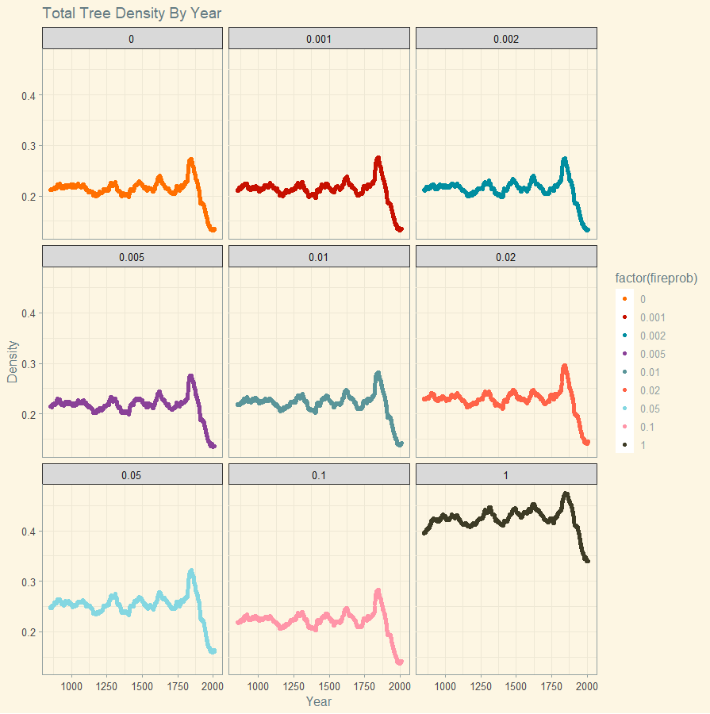

#### Figure 2: Total Tree Density Through Year - Sequential

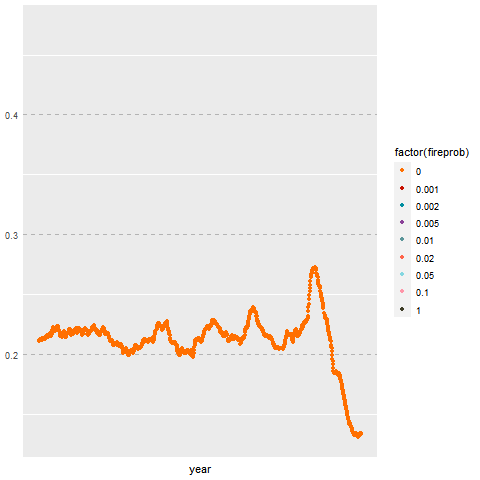

#### Figure 3: Total Tree Density Through Year: Side by Side

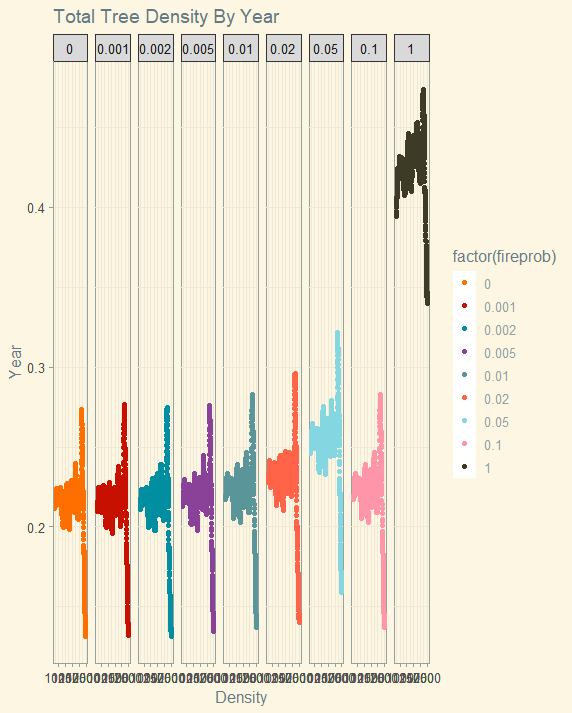

Since `Density` was trending consistently through `Year`, I decided to run a separate analysis without `Year` as a consideration. Figure 4 is `Plant Density` by `Fire Probability`, separated by `Plant Functional Type`. What I found in this analysis was intriguing; while the `Total Density` markers reflect the output produced in the previous analysis (Rise in `Total Plant Density` on `Fire Probability` 0.05 and 1), the individual `Plant Functional Types` do not all align neatly. While `BNT`, `BNI`, and `TBT` rise on the `Fire Probability` 0.05 and 1 markers, `BBI`, `TBI`, and `TBIR` reverse.

When presented to the group, this was somewhat unexpected. However, we have thought about the results and determined that it may mean that the LPJ-Guess and Charlottes’ inputs are working correctly - on further analysis, we came to the conclusion that we should not expect all PFTs to function the same with regards to `Density` and `Fire Frequency`, as they have different traits, weaknesses, and strengths.

We are looking to investigate this further; I am currently awaiting additional data from Charlotte, specifically `Tree Diameter` - which we hope will further help us uncover the secrets of this virtual forest.

#### Figure 4: Plant Density by Fire Probability, Seperated by PFT

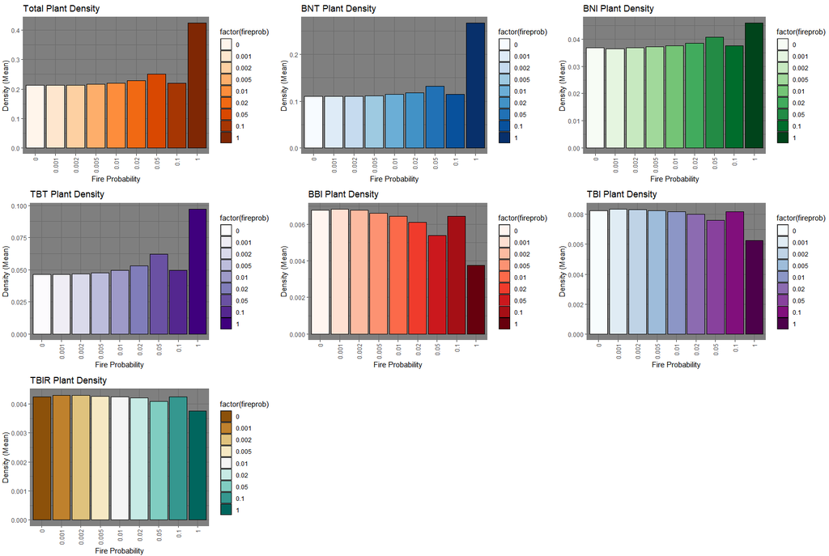

### Code

```r
####
## Library Load
####
library("ggplot2")
library("dplyr")
library("gridExtra")
library("quantreg")
library("gganimate")
library("animation")
library("transformr")
library("viridis")
library("tidyverse")
library("ggsci")
library("ggpubr")
library("gganimate")
library("magick")
library("ggthemes")
library("tidyverse")
library("rmdformats") # added 3/3/2020
library("hrbrthemes") # added 3/3/2020
library("broom") # added 3/9 for data sci modeling
library("leaflet") # added 3/11 data sci
library("socviz")# added 3/11 data sci
library("maps")# added 3/11 data sci
library("grid")# added 3/11 data sci
library("statebins")# added 3/11 data sci
library("usmap")# added 3/11 data sci
library('gmodels') # added for Data Sci - Machine Learning
library('gapminder') # added for Data Sci
## Font Package ##
library('extrafontdb')
library('Rttf2pt1')
library('extrafont')
library('gcookbook')
library('scales')
### Charlotte Packages ###
#library(ggplot2) #for plotting
#library(dplyr) #changing data structure: mutate() and filter() are great
#library(plyr) #use aggreggate() funciton for changing data format
#library(reshape2) #also helpful for reshaping data: melt() and dcast()
#library(tidyr) #agian, has a bunch of data reshaping funcitons
#library(raster) #if you want to map something, this will turn data into spatial object
#library(gstat) #or modellign if you want to do fancier things than just  a linear model
#library(ggthemes) #for pretty plots
##################





### //=\\ Data Read //=\\
### ::::::::::::::::::::: ###
den1 = read.table('density_output/dens1.out')                        ## Fire Prob: 1
den0 = read.table('density_output/dens-pop-density-0.out')           ## Fire Prob: 0
den0.1 = read.table('density_output/dens-0-01.out')                  ## Fire Prob: 0.1
den0.05 = read.table('density_output/dens-0-05.out')                 ## Fire Prob: 0.05
den0.02 = read.table('density_output/dens-0-02.out')                 ## Fire Prob: 0.02
den0.01 = read.table('density_output/dens-0-01.out')                 ## Fire Prob: 0.01
den0.005 = read.table('density_output/dens-0-005.out')               ## Fire Prob: 0.005
den0.002 = read.table('density_output/dens-0-002.out')               ## Fire Prob: 0.002
den0.001 = read.table('density_output/dens-0-001.out')               ## Fire Prob: 0.001
denInd = read.table('density_output/dens-indigenous-pop-density.out')## Fire Prob: Indigenous
### :::::::::::::::::::::: ###




### //[F]\\ Charlotte Function //[F]\\
### ::::::::::::::::::::: ###
cleanup <- function(data=x, fireprob=y) {
  #rename columns
  names(data) <- c("Lon","Lat","year","BNT","BNI","TBT","BBI","TBI","TBIR", "C3G", "C4G","Total")
  #remove first row - for some reason output had headers as athe firs row
  data <- data[-c(1),]
  data[,1] <- as.numeric(paste(data$Lon))
  data[,2] <- as.numeric(paste(data$Lat))
  data[,3] <- as.numeric(paste(data$year))
  data[,4] <- as.numeric(paste(data$BNT))
  data[,5] <- as.numeric(paste(data$BNI))
  data[,6] <- as.numeric(paste(data$TBT))
  data[,7] <- as.numeric(paste(data$BBI))
  data[,8] <- as.numeric(paste(data$TBI))
  data[,9] <- as.numeric(paste(data$TBIR))
  data[,10] <- as.numeric(paste(data$C3G))
  data[,11] <- as.numeric(paste(data$C4G))
  data[,12] <- as.numeric(paste(data$Total))

  #add a column with fire probability
  fireprob <- rep(fireprob, times=nrow(data))
  data <- cbind(data, fireprob)

  return(data)
}
### ::::::::::::::::::::: ###



### //[C]\\ Data Clean //[C]\\
### Apply Setup Function to All Data
### ::::::::::::::::::::: ###
den1 = cleanup(den1, 1)                 ## [C] Fire Prob: 1
den0 = cleanup(den0, 0)                 ## [C] Fire Prob: 0
den0.1 = cleanup(den0.1, 0.1)           ## [C] Fire Prob: 0.1
den0.05 = cleanup(den0.05, 0.05)        ## [C] Fire Prob: 0.05
den0.02 = cleanup(den0.02, 0.02)        ## [C] Fire Prob: 0.02
den0.01 = cleanup(den0.01, 0.01)        ## [C] Fire Prob: 0.01
den0.005 = cleanup(den0.005, 0.005)     ## [C] Fire Prob: 0.005
den0.002 = cleanup(den0.002, 0.002)     ## [C] Fire Prob: 0.002
den0.001 = cleanup(den0.001, 0.001)     ## [C] Fire Prob: 0.001
### denInd = cleanup(denInd, ## Need Number
### ::::::::::::::::::::: ###


### Preliminary Visualization Of Totals



### /////////|||||::|||||\\\\\\\ ###
#### TOTAL SET ####
### Den 1 ###
den1_prelim <- den1 %>%
  group_by(year)
## Sum Set
den1_prelim <- den1_prelim %>% summarize(
  total = mean(Total),
  fireprob = fireprob)


### Den 0 ###
den0_prelim <- den0 %>%
  group_by(year)
## Sum Set
den0_prelim <- den0_prelim %>% summarize(
  total = mean(Total),
  fireprob = fireprob)


### Den 0.1 ###
den0.1_prelim <- den0.1 %>%
  group_by(year)
## Sum Set
den0.1_prelim <- den0.1_prelim %>% summarize(
  total = mean(Total),
  fireprob = fireprob)


### Den 0.05 ###
den0.05_prelim <- den0.05 %>%
  group_by(year)
## Sum Set
den0.05_prelim <- den0.05_prelim %>% summarize(
  total = mean(Total),
  fireprob = fireprob)


### Den 0.02 ###
den0.02_prelim <- den0.02 %>%
  group_by(year)
## Sum Set
den0.02_prelim <- den0.02_prelim %>% summarize(
  total = mean(Total),
  fireprob = fireprob)


### Den 0.01 ###
den0.01_prelim <- den0.01 %>%
  group_by(year)
## Sum Set
den0.01_prelim <- den0.01_prelim %>% summarize(
  total = mean(Total),
  fireprob = fireprob)


### Den 0.005 ###
den0.005_prelim <- den0.005 %>%
  group_by(year)
## Sum Set
den0.005_prelim <- den0.005_prelim %>% summarize(
  total = mean(Total),
  fireprob = fireprob)


### Den 0.002 ###
den0.002_prelim <- den0.002 %>%
  group_by(year)
## Sum Set
den0.002_prelim <- den0.002_prelim %>% summarize(
  total = mean(Total),
  fireprob = fireprob)


### Den 0.001 ###
den0.001_prelim <- den0.001 %>%
  group_by(year)
## Sum Set
den0.001_prelim <- den0.001_prelim %>% summarize(
  total = mean(Total),
  fireprob = fireprob)
### ::::::::::::::::::::: ###




### Merge All Data, Use Fireprob as Divider ###
### ::::::::::::::::::::: ###
all_density <- den1_prelim %>%
  full_join(den0_prelim) %>%
  full_join(den0.1_prelim) %>%
  full_join(den0.05_prelim) %>%
  full_join(den0.02_prelim) %>%
  full_join(den0.01_prelim) %>%
  full_join(den0.005_prelim) %>%
  full_join(den0.002_prelim) %>%
  full_join(den0.001_prelim)
### ::::::::::::::::::::: ###
```

```r
##
total_plot <- ggplot(data = all_density,
       mapping = aes(x = year, y = total, color = factor(fireprob)))+
  geom_point()+
  facet_wrap(~fireprob, ncol = 3)+
  theme_solarized()+
  scale_x_continuous(n.breaks = 5)+
  scale_color_futurama()+
  labs(title = "Total Tree Density By Year", x = "Year", y = "Density")

### Summary Stats of Total
total_sum <- all_density %>%
  group_by(year) %>%
  group_by(fireprob) %>%
  summarize(
    total = mean(total))





### /////////|||||::|||||\\\\\\\ ###




### /////////|||||::|||||\\\\\\\ ###
#### BNT SET ####
### Den 1 ###
den1_prelim <- den1 %>%
  group_by(year)
## Sum Set
den1_prelim <- den1_prelim %>% summarize(
  total = mean(BNT),
  fireprob = fireprob)


### Den 0 ###
den0_prelim <- den0 %>%
  group_by(year)
## Sum Set
den0_prelim <- den0_prelim %>% summarize(
  total = mean(BNT),
  fireprob = fireprob)


### Den 0.1 ###
den0.1_prelim <- den0.1 %>%
  group_by(year)
## Sum Set
den0.1_prelim <- den0.1_prelim %>% summarize(
  total = mean(BNT),
  fireprob = fireprob)


### Den 0.05 ###
den0.05_prelim <- den0.05 %>%
  group_by(year)
## Sum Set
den0.05_prelim <- den0.05_prelim %>% summarize(
  total = mean(BNT),
  fireprob = fireprob)


### Den 0.02 ###
den0.02_prelim <- den0.02 %>%
  group_by(year)
## Sum Set
den0.02_prelim <- den0.02_prelim %>% summarize(
  total = mean(BNT),
  fireprob = fireprob)


### Den 0.01 ###
den0.01_prelim <- den0.01 %>%
  group_by(year)
## Sum Set
den0.01_prelim <- den0.01_prelim %>% summarize(
  total = mean(BNT),
  fireprob = fireprob)


### Den 0.005 ###
den0.005_prelim <- den0.005 %>%
  group_by(year)
## Sum Set
den0.005_prelim <- den0.005_prelim %>% summarize(
  total = mean(BNT),
  fireprob = fireprob)


### Den 0.002 ###
den0.002_prelim <- den0.002 %>%
  group_by(year)
## Sum Set
den0.002_prelim <- den0.002_prelim %>% summarize(
  total = mean(BNT),
  fireprob = fireprob)


### Den 0.001 ###
den0.001_prelim <- den0.001 %>%
  group_by(year)
## Sum Set
den0.001_prelim <- den0.001_prelim %>% summarize(
  total = mean(BNT),
  fireprob = fireprob)
### ::::::::::::::::::::: ###




### Merge All Data, Use Fireprob as Divider ###
### ::::::::::::::::::::: ###
all_density <- den1_prelim %>%
  full_join(den0_prelim) %>%
  full_join(den0.1_prelim) %>%
  full_join(den0.05_prelim) %>%
  full_join(den0.02_prelim) %>%
  full_join(den0.01_prelim) %>%
  full_join(den0.005_prelim) %>%
  full_join(den0.002_prelim) %>%
  full_join(den0.001_prelim)
### ::::::::::::::::::::: ###


##
##
##
bnt_plot <- ggplot(data = all_density,
                     mapping = aes(x = year, y = total, color = factor(fireprob)))+
  geom_point()+
  facet_wrap(~fireprob, ncol = 3)+
  theme_solarized()+
  scale_x_continuous(n.breaks = 5)+
  scale_color_futurama()+
  labs(title = "BNT Tree Density By Year", x = "Year", y = "Density")

### Summary Stats of Total
bnt_sum <- all_density %>%
  group_by(year) %>%
  group_by(fireprob) %>%
  summarize(
    total = mean(total))

### /////////|||||::|||||\\\\\\\ ###





### /////////|||||::|||||\\\\\\\ ###
#### BNI SET ####
### Den 1 ###
den1_prelim <- den1 %>%
  group_by(year)
## Sum Set
den1_prelim <- den1_prelim %>% summarize(
  total = mean(BNI),
  fireprob = fireprob)


### Den 0 ###
den0_prelim <- den0 %>%
  group_by(year)
## Sum Set
den0_prelim <- den0_prelim %>% summarize(
  total = mean(BNI),
  fireprob = fireprob)


### Den 0.1 ###
den0.1_prelim <- den0.1 %>%
  group_by(year)
## Sum Set
den0.1_prelim <- den0.1_prelim %>% summarize(
  total = mean(BNI),
  fireprob = fireprob)


### Den 0.05 ###
den0.05_prelim <- den0.05 %>%
  group_by(year)
## Sum Set
den0.05_prelim <- den0.05_prelim %>% summarize(
  total = mean(BNI),
  fireprob = fireprob)


### Den 0.02 ###
den0.02_prelim <- den0.02 %>%
  group_by(year)
## Sum Set
den0.02_prelim <- den0.02_prelim %>% summarize(
  total = mean(BNI),
  fireprob = fireprob)


### Den 0.01 ###
den0.01_prelim <- den0.01 %>%
  group_by(year)
## Sum Set
den0.01_prelim <- den0.01_prelim %>% summarize(
  total = mean(BNI),
  fireprob = fireprob)


### Den 0.005 ###
den0.005_prelim <- den0.005 %>%
  group_by(year)
## Sum Set
den0.005_prelim <- den0.005_prelim %>% summarize(
  total = mean(BNI),
  fireprob = fireprob)


### Den 0.002 ###
den0.002_prelim <- den0.002 %>%
  group_by(year)
## Sum Set
den0.002_prelim <- den0.002_prelim %>% summarize(
  total = mean(BNI),
  fireprob = fireprob)


### Den 0.001 ###
den0.001_prelim <- den0.001 %>%
  group_by(year)
## Sum Set
den0.001_prelim <- den0.001_prelim %>% summarize(
  total = mean(BNI),
  fireprob = fireprob)
### ::::::::::::::::::::: ###




### Merge All Data, Use Fireprob as Divider ###
### ::::::::::::::::::::: ###
all_density <- den1_prelim %>%
  full_join(den0_prelim) %>%
  full_join(den0.1_prelim) %>%
  full_join(den0.05_prelim) %>%
  full_join(den0.02_prelim) %>%
  full_join(den0.01_prelim) %>%
  full_join(den0.005_prelim) %>%
  full_join(den0.002_prelim) %>%
  full_join(den0.001_prelim)
### ::::::::::::::::::::: ###


##
bni_plot <- ggplot(data = all_density,
                     mapping = aes(x = year, y = total, color = factor(fireprob)))+
  geom_point()+
  facet_wrap(~fireprob, ncol = 3)+
  theme_solarized()+
  scale_x_continuous(n.breaks = 5)+
  scale_color_futurama()+
  labs(title = "BNI Tree Density By Year", x = "Year", y = "Density")

### Summary Stats of Total
bni_sum <- all_density %>%
  group_by(year) %>%
  group_by(fireprob) %>%
  summarize(
    total = mean(total))

### /////////|||||::|||||\\\\\\\ ###





### /////////|||||::|||||\\\\\\\ ###
#### TBT SET ####
### Den 1 ###
den1_prelim <- den1 %>%
  group_by(year)
## Sum Set
den1_prelim <- den1_prelim %>% summarize(
  total = mean(TBT),
  fireprob = fireprob)


### Den 0 ###
den0_prelim <- den0 %>%
  group_by(year)
## Sum Set
den0_prelim <- den0_prelim %>% summarize(
  total = mean(TBT),
  fireprob = fireprob)


### Den 0.1 ###
den0.1_prelim <- den0.1 %>%
  group_by(year)
## Sum Set
den0.1_prelim <- den0.1_prelim %>% summarize(
  total = mean(TBT),
  fireprob = fireprob)
```

```r
### Den 0.05 ###
den0.05_prelim <- den0.05 %>%
  group_by(year)
## Sum Set
den0.05_prelim <- den0.05_prelim %>% summarize(
  total = mean(TBT),
  fireprob = fireprob)


### Den 0.02 ###
den0.02_prelim <- den0.02 %>%
  group_by(year)
## Sum Set
den0.02_prelim <- den0.02_prelim %>% summarize(
  total = mean(TBT),
  fireprob = fireprob)


### Den 0.01 ###
den0.01_prelim <- den0.01 %>%
  group_by(year)
## Sum Set
den0.01_prelim <- den0.01_prelim %>% summarize(
  total = mean(TBT),
  fireprob = fireprob)


### Den 0.005 ###
den0.005_prelim <- den0.005 %>%
  group_by(year)
## Sum Set
den0.005_prelim <- den0.005_prelim %>% summarize(
  total = mean(TBT),
  fireprob = fireprob)


### Den 0.002 ###
den0.002_prelim <- den0.002 %>%
  group_by(year)
## Sum Set
den0.002_prelim <- den0.002_prelim %>% summarize(
  total = mean(TBT),
  fireprob = fireprob)


### Den 0.001 ###
den0.001_prelim <- den0.001 %>%
  group_by(year)
## Sum Set
den0.001_prelim <- den0.001_prelim %>% summarize(
  total = mean(TBT),
  fireprob = fireprob)
### ::::::::::::::::::::: ###




### Merge All Data, Use Fireprob as Divider ###
### ::::::::::::::::::::: ###
all_density <- den1_prelim %>%
  full_join(den0_prelim) %>%
  full_join(den0.1_prelim) %>%
  full_join(den0.05_prelim) %>%
  full_join(den0.02_prelim) %>%
  full_join(den0.01_prelim) %>%
  full_join(den0.005_prelim) %>%
  full_join(den0.002_prelim) %>%
  full_join(den0.001_prelim)
### ::::::::::::::::::::: ###


##
tbt_plot <- ggplot(data = all_density,
                   mapping = aes(x = year, y = total, color = factor(fireprob)))+
  geom_point()+
  facet_wrap(~fireprob, ncol = 3)+
  theme_solarized()+
  scale_x_continuous(n.breaks = 5)+
  scale_color_futurama()+
  labs(title = "TBT Tree Density By Year", x = "Year", y = "Density")

### Summary Stats of Total
tbt_sum <- all_density %>%
  group_by(year) %>%
  group_by(fireprob) %>%
  summarize(
    total = mean(total))
### /////////|||||::|||||\\\\\\\ ###



### /////////|||||::|||||\\\\\\\ ###
#### BBI SET ####
### Den 1 ###
den1_prelim <- den1 %>%
  group_by(year)
## Sum Set
den1_prelim <- den1_prelim %>% summarize(
  total = mean(BBI),
  fireprob = fireprob)


### Den 0 ###
den0_prelim <- den0 %>%
  group_by(year)
## Sum Set
den0_prelim <- den0_prelim %>% summarize(
  total = mean(BBI),
  fireprob = fireprob)


### Den 0.1 ###
den0.1_prelim <- den0.1 %>%
  group_by(year)
## Sum Set
den0.1_prelim <- den0.1_prelim %>% summarize(
  total = mean(BBI),
  fireprob = fireprob)


### Den 0.05 ###
den0.05_prelim <- den0.05 %>%
  group_by(year)
## Sum Set
den0.05_prelim <- den0.05_prelim %>% summarize(
  total = mean(BBI),
  fireprob = fireprob)


### Den 0.02 ###
den0.02_prelim <- den0.02 %>%
  group_by(year)
## Sum Set
den0.02_prelim <- den0.02_prelim %>% summarize(
  total = mean(BBI),
  fireprob = fireprob)


### Den 0.01 ###
den0.01_prelim <- den0.01 %>%
  group_by(year)
## Sum Set
den0.01_prelim <- den0.01_prelim %>% summarize(
  total = mean(BBI),
  fireprob = fireprob)


### Den 0.005 ###
den0.005_prelim <- den0.005 %>%
  group_by(year)
## Sum Set
den0.005_prelim <- den0.005_prelim %>% summarize(
  total = mean(BBI),
  fireprob = fireprob)


### Den 0.002 ###
den0.002_prelim <- den0.002 %>%
  group_by(year)
## Sum Set
den0.002_prelim <- den0.002_prelim %>% summarize(
  total = mean(BBI),
  fireprob = fireprob)


### Den 0.001 ###
den0.001_prelim <- den0.001 %>%
  group_by(year)
## Sum Set
den0.001_prelim <- den0.001_prelim %>% summarize(
  total = mean(BBI),
  fireprob = fireprob)
### ::::::::::::::::::::: ###




### Merge All Data, Use Fireprob as Divider ###
### ::::::::::::::::::::: ###
all_density <- den1_prelim %>%
  full_join(den0_prelim) %>%
  full_join(den0.1_prelim) %>%
  full_join(den0.05_prelim) %>%
  full_join(den0.02_prelim) %>%
  full_join(den0.01_prelim) %>%
  full_join(den0.005_prelim) %>%
  full_join(den0.002_prelim) %>%
  full_join(den0.001_prelim)
### ::::::::::::::::::::: ###


##
bbi_plot <- ggplot(data = all_density,
       mapping = aes(x = year, y = total, color = factor(fireprob)))+
  geom_point()+
  facet_wrap(~fireprob, ncol = 3)+
  theme_solarized_2()+
  scale_x_continuous(n.breaks = 5)+
  scale_color_futurama()+
  labs(title = "BBI Tree Density By Year", x = "Year", y = "Density")


### Summary Stats of Total
bbi_sum <- all_density %>%
  group_by(year) %>%
  group_by(fireprob) %>%
  summarize(
    total = mean(total))
### /////////|||||::|||||\\\\\\\ ###



### /////////|||||::|||||\\\\\\\ ###
#### TBI SET ####
### Den 1 ###
den1_prelim <- den1 %>%
  group_by(year)
## Sum Set
den1_prelim <- den1_prelim %>% summarize(
  total = mean(TBI),
  fireprob = fireprob)


### Den 0 ###
den0_prelim <- den0 %>%
  group_by(year)
## Sum Set
den0_prelim <- den0_prelim %>% summarize(
  total = mean(TBI),
  fireprob = fireprob)


### Den 0.1 ###
den0.1_prelim <- den0.1 %>%
  group_by(year)
## Sum Set
den0.1_prelim <- den0.1_prelim %>% summarize(
  total = mean(TBI),
  fireprob = fireprob)


### Den 0.05 ###
den0.05_prelim <- den0.05 %>%
  group_by(year)
## Sum Set
den0.05_prelim <- den0.05_prelim %>% summarize(
  total = mean(TBI),
  fireprob = fireprob)


### Den 0.02 ###
den0.02_prelim <- den0.02 %>%
  group_by(year)
## Sum Set
den0.02_prelim <- den0.02_prelim %>% summarize(
  total = mean(TBI),
  fireprob = fireprob)


### Den 0.01 ###
den0.01_prelim <- den0.01 %>%
  group_by(year)
## Sum Set
den0.01_prelim <- den0.01_prelim %>% summarize(
  total = mean(TBI),
  fireprob = fireprob)


### Den 0.005 ###
den0.005_prelim <- den0.005 %>%
  group_by(year)
## Sum Set
den0.005_prelim <- den0.005_prelim %>% summarize(
  total = mean(TBI),
  fireprob = fireprob)


### Den 0.002 ###
den0.002_prelim <- den0.002 %>%
  group_by(year)
## Sum Set
den0.002_prelim <- den0.002_prelim %>% summarize(
  total = mean(TBI),
  fireprob = fireprob)


### Den 0.001 ###
den0.001_prelim <- den0.001 %>%
  group_by(year)
## Sum Set
den0.001_prelim <- den0.001_prelim %>% summarize(
  total = mean(TBI),
  fireprob = fireprob)
### ::::::::::::::::::::: ###
```

```r
### Merge All Data, Use Fireprob as Divider ###
### ::::::::::::::::::::: ###
all_density <- den1_prelim %>%
  full_join(den0_prelim) %>%
  full_join(den0.1_prelim) %>%
  full_join(den0.05_prelim) %>%
  full_join(den0.02_prelim) %>%
  full_join(den0.01_prelim) %>%
  full_join(den0.005_prelim) %>%
  full_join(den0.002_prelim) %>%
  full_join(den0.001_prelim)
### ::::::::::::::::::::: ###


##
tbi_plot <- ggplot(data = all_density,
       mapping = aes(x = year, y = total, color = factor(fireprob)))+
  geom_point()+
  facet_wrap(~fireprob, ncol = 3)+
  theme_solarized_2()+
  scale_x_continuous(n.breaks = 5)+
  scale_color_futurama()+
  labs(title = "TBI Tree Density By Year", x = "Year", y = "Density")

### Summary Stats of Total
tbi_sum <- all_density %>%
  group_by(year) %>%
  group_by(fireprob) %>%
  summarize(
    total = mean(total))
### /////////|||||::|||||\\\\\\\ ###




### /////////|||||::|||||\\\\\\\ ###
#### TBIR SET ####
### Den 1 ###
den1_prelim <- den1 %>%
  group_by(year)
## Sum Set
den1_prelim <- den1_prelim %>% summarize(
  total = mean(TBIR),
  fireprob = fireprob)


### Den 0 ###
den0_prelim <- den0 %>%
  group_by(year)
## Sum Set
den0_prelim <- den0_prelim %>% summarize(
  total = mean(TBIR),
  fireprob = fireprob)


### Den 0.1 ###
den0.1_prelim <- den0.1 %>%
  group_by(year)
## Sum Set
den0.1_prelim <- den0.1_prelim %>% summarize(
  total = mean(TBIR),
  fireprob = fireprob)


### Den 0.05 ###
den0.05_prelim <- den0.05 %>%
  group_by(year)
## Sum Set
den0.05_prelim <- den0.05_prelim %>% summarize(
  total = mean(TBIR),
  fireprob = fireprob)


### Den 0.02 ###
den0.02_prelim <- den0.02 %>%
  group_by(year)
## Sum Set
den0.02_prelim <- den0.02_prelim %>% summarize(
  total = mean(TBIR),
  fireprob = fireprob)


### Den 0.01 ###
den0.01_prelim <- den0.01 %>%
  group_by(year)
## Sum Set
den0.01_prelim <- den0.01_prelim %>% summarize(
  total = mean(TBIR),
  fireprob = fireprob)


### Den 0.005 ###
den0.005_prelim <- den0.005 %>%
  group_by(year)
## Sum Set
den0.005_prelim <- den0.005_prelim %>% summarize(
  total = mean(TBIR),
  fireprob = fireprob)


### Den 0.002 ###
den0.002_prelim <- den0.002 %>%
  group_by(year)
## Sum Set
den0.002_prelim <- den0.002_prelim %>% summarize(
  total = mean(TBIR),
  fireprob = fireprob)


### Den 0.001 ###
den0.001_prelim <- den0.001 %>%
  group_by(year)
## Sum Set
den0.001_prelim <- den0.001_prelim %>% summarize(
  total = mean(TBIR),
  fireprob = fireprob)
### ::::::::::::::::::::: ###




### Merge All Data, Use Fireprob as Divider ###
### ::::::::::::::::::::: ###
all_density <- den1_prelim %>%
  full_join(den0_prelim) %>%
  full_join(den0.1_prelim) %>%
  full_join(den0.05_prelim) %>%
  full_join(den0.02_prelim) %>%
  full_join(den0.01_prelim) %>%
  full_join(den0.005_prelim) %>%
  full_join(den0.002_prelim) %>%
  full_join(den0.001_prelim)
### ::::::::::::::::::::: ###


##
tbir_plot <- ggplot(data = all_density,
       mapping = aes(x = year, y = total, color = factor(fireprob)))+
  geom_point()+
  facet_wrap(~fireprob, ncol = 3)+
  theme_solarized_2()+
  scale_x_continuous(n.breaks = 5)+
  scale_color_futurama()+
  labs(title = "TBIR Tree Density By Year", x = "Year", y = "Density")

### Summary Stats of Total
tbir_sum <- all_density %>%
  group_by(year) %>%
  group_by(fireprob) %>%
  summarize(
    total = mean(total))
### /////////|||||::|||||\\\\\\\ ###
```

```r
### //---Summary---\\ ###
total_sum
```

```
## # A tibble: 9 x 2
##   fireprob total
##      <dbl> <dbl>
## 1    0     0.212
## 2    0.001 0.212
## 3    0.002 0.213
## 4    0.005 0.216
## 5    0.01  0.220
## 6    0.02  0.228
## 7    0.05  0.251
## 8    0.1   0.220
## 9    1     0.424
```

```r
bnt_sum
```

```
## # A tibble: 9 x 2
##   fireprob total
##      <dbl> <dbl>
## 1    0     0.110
## 2    0.001 0.110
## 3    0.002 0.110
## 4    0.005 0.112
## 5    0.01  0.114
## 6    0.02  0.118
## 7    0.05  0.131
## 8    0.1   0.114
## 9    1     0.267
```

```r
bni_sum
```

```
## # A tibble: 9 x 2
##   fireprob  total
##      <dbl>  <dbl>
## 1    0     0.0367
## 2    0.001 0.0365
## 3    0.002 0.0368
## 4    0.005 0.0372
## 5    0.01  0.0376
## 6    0.02  0.0385
## 7    0.05  0.0408
## 8    0.1   0.0376
## 9    1     0.0459
```

```r
tbt_sum
```

```
## # A tibble: 9 x 2
##   fireprob  total
##      <dbl>  <dbl>
## 1    0     0.0464
## 2    0.001 0.0462
## 3    0.002 0.0466
## 4    0.005 0.0476
## 5    0.01  0.0495
## 6    0.02  0.0529
## 7    0.05  0.0621
## 8    0.1   0.0495
## 9    1     0.0971
```

```r
bbi_sum
```

```
## # A tibble: 9 x 2
##   fireprob   total
##      <dbl>   <dbl>
## 1    0     0.00676
## 2    0.001 0.00683
## 3    0.002 0.00678
## 4    0.005 0.00661
## 5    0.01  0.00644
## 6    0.02  0.00610
## 7    0.05  0.00540
## 8    0.1   0.00644
## 9    1     0.00377
```

```r
tbi_sum
```

```
## # A tibble: 9 x 2
##   fireprob   total
##      <dbl>   <dbl>
## 1    0     0.00825
## 2    0.001 0.00835
## 3    0.002 0.00832
## 4    0.005 0.00824
## 5    0.01  0.00818
## 6    0.02  0.00802
## 7    0.05  0.00761
## 8    0.1   0.00818
## 9    1     0.00626
```

```r
tbir_sum
```

```
## # A tibble: 9 x 2
##   fireprob   total
##      <dbl>   <dbl>
## 1    0     0.00425
## 2    0.001 0.00430
## 3    0.002 0.00429
## 4    0.005 0.00426
## 5    0.01  0.00425
## 6    0.02  0.00421
## 7    0.05  0.00409
## 8    0.1   0.00425
## 9    1     0.00376
```

```r
###########
```